# 14_A_TS_CrossValidation

# References

NOTE: the following material not fully original, but rather an extension of reference 1 with comments and other sources to improve the student’s understanding:

1. Hyndman, R.J., & Athanasopoulos, G., 2021. *Forecasting: principles and practice*. 3rd edition.
2. Fable package documentation
- https://fable.tidyverts.org/index.html
- https://fable.tidyverts.org/articles/fable.html

# Packages

```r
library(fpp3)
```

# Time Series Cross-Validation

## Introduction to the concept

Evaluating accuracy on a **single test-train split** yields results that are very dependent on the particular split performed.

To get more statistically robust results, we may:

1. Compute error metrics on many different train-test splits.
2. Average the results obtained for each split.

This simple idea is what we refer to as `cross-validation`.

## Cross-validation in time series

Cross-validation applied to time series consists of:

1. **Generating a series of train-test splits.** These splits must respect the aspects below:
   - **They must respect the time-order structure of the data**. Unlike in other areas of ML, where train-test splits are done using random sampling techniques, here the time structure of the data must be respected.
   - **Training sets need a minimum size** $\rightarrow$ the earliest observations cannot be used as test sets, or the training set would be too small.
   - **The smallest training dataset should be at least as large as the maximum forecast horizon required.** If possible, the smallest training dataset should be bigger than this.
   - The training set shall only contain observations that occurred **prior** to the observations of the test set.
   - **All the test sets must have the same length**, and must be placed in time **after the training set**.
2. **Compute the point forecast accuracy metrics for each of the different train-test splits generated, and average them.**

Again, it is essential to respect the time structure of the data when performing these splits.

## Visualizing the train-test splits

**Problem:** given a time series, we are to fit multiple models and evaluate their performance using cross-validation. **Input**: the corresponding values of the time series $y_t$ at a series of points in time, depicted below in grey. For simplicity, I only depict the points in time, without depicting the values $y_t$:

[figure not shown]

Instead of splitting this time series in a single train-test split, we are going to **generate multiple train-test splits based on this original time series**.

### Example 1: one-step ahead forecasts

Let us start with a simple example, in which:

1. Training sets have an initial size and grow one observation at a time.
2. Test sets consist of a single observation, with forecast horizon h = 1.

The diagram below represents this situation:

- Blue observations represent the training sets
- Orange observations represent the test sets.

[figure not shown]

Performing cross-validation based on this series of train-test sets means:

1. Fit the models to each of the training sets.
2. For each model fitted to each training set, evaluate the forecast errors on their corresponding test set.
3. Compute the average of the resulting forecast errors over all the train-test splits.

**Result**: average errors over all the training datasets of each model for the forecast horizon being considered (in the example h = 1)

### Example 2: multi-step forecasts

For multi-step forecasts, the same strategy is followed. This time the test set is at a distance `h` (the forecast horizon) from the training set.

Suppose we are interested in models that produce good 4-step-ahead forecasts. The corresponding train-test splits would be:

[figure not shown]

Again, performing cross-validation based on this series of train-test sets means:

1. Fit the models to each of the training sets.
2. For each model fitted to each training set, evaluate the forecast errors on their corresponding test set.
3. Compute the average of the resulting forecast errors over all the train-test splits.

**Result**: average errors over all the training datasets of each model for the forecast horizon being considered (in the example h = 4)

### Example 3: cross-validation for multiple forecast horizons

In practice we are interested in analyzing which model performs best across a series of forecast horizons, not just for a specific one. For this purpose we need train-test splits that look like those in the figure below. The difference is that the test sets now include more than one forecast horizon.

- With the splits in the example, we could analyze forecast horizons of up to h = 4.

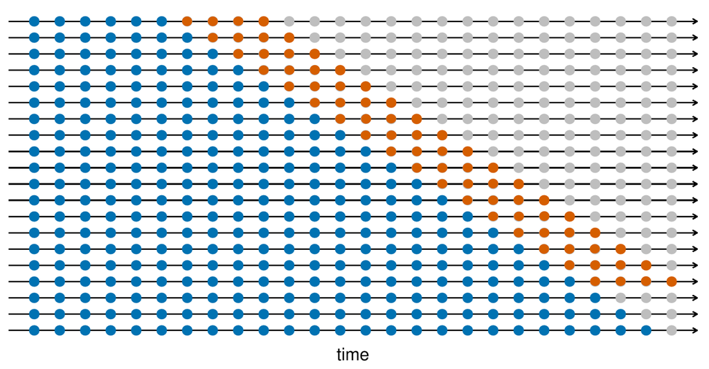

With these train-test splits, cross-validation can be performed at two levels:

1. **Performance of the different models for each forecast horizon separately.**
   - Result: average performance metrics over all training datasets for each combination of:
     - Model.
     - Forecast horizon.
2. **Performance of the different models on average across all forecast horizons.**
   - Result: average performance metrics over all training datasets and forecast horizons for each model.

#### Option 1: performance of the different models for each forecast horizon separately

1. Fit the models to each of the training sets.
2. For each model fitted to each training set, evaluate the forecast errors on their corresponding test set, separately for each forecast horizon.
3. For each combination of model and forecast horizon, compute the average of the resulting errors over all the train-test splits.

**Result**: average errors of each model over all the training datasets for every forecast horizon being considered (in the example for h = 1, 2, 3 and 4).

- That is, we would obtain **h results per model** (average error for each forecast horizon).

#### Option 2: performance of the different models averaged over all the forecast horizons

1. Fit the models to each of the training sets.
2. For each model fitted to each training set, evaluate the forecast errors on their corresponding test set, separately for each forecast horizon.
3. For each combination of model and forecast horizon, compute the average of the resulting errors over all the train-test splits.
4. For each model compute the average over all forecast horizons.

**Result**: average errors of each model over all the training datasets and forecast horizons.

- That is, we would obtain **1 result per model** (error averaged over all forecast horizons)

## Function `stretch_tsibble()`

Let us move to the practical aspects of how to obtain these multiple train-test splits in R.

The function `stretch_tsibble()` is used in the `fable` library to create many training sets for cross-validation (this library is loaded along with `fpp3`). Arguments:

`stretch_tsibble(.x, .step = 1, .init = 1)`

- `.x`: tsibble to be split following the time series cross-validation strategy.
- `.step`: a positive integer specifying the growth rate of the training sets. That is, how many observations at a time are added to the training datasets. Default: `.step = 1`.
- `.init`: a positive integer for the initial size of the training set. Default: `.init = 1`.

Remember the indications given above about the minimum sizes of the training datasets.

The figure below summarizes the meaning of these arguments applied to one of the examples given before (you can zoom in on the .html file to enlarge it).

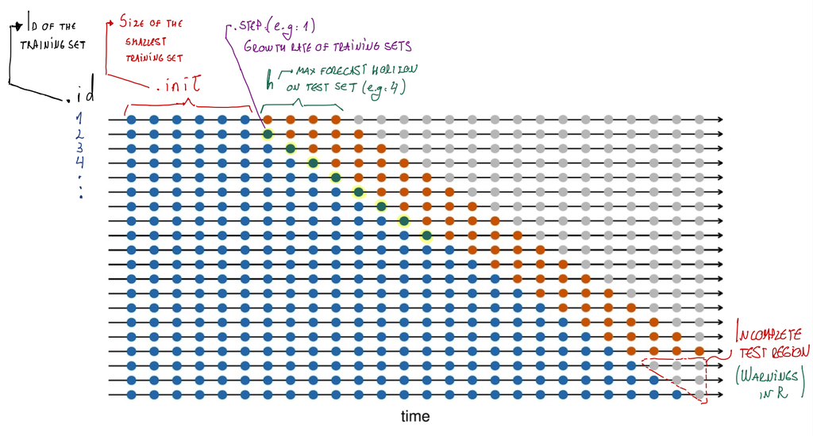

## Detailed example of time series cross-validation

We will use the data for google stock closing prices on 2015:

```r
google_stock <- gafa_stock |>
  filter(Symbol == "GOOG", year(Date) >= 2015) |>
  mutate(day = row_number()) |>
  update_tsibble(index = day, regular = TRUE)
```

```r
google_2015 <-
  google_stock |>
  filter(year(Date) == 2015) |>
  select(everything(), -Symbol)
```

### Step 1. Create the set of training datasets using `stretch_tsibble()`:

```r
google_2015_tr <- google_2015 |>
  stretch_tsibble(.init = 20, .step = 1) |>
  relocate(Date, .id) # reorder column

google_2015_tr
```

```
# A tsibble: 31,688 x 9 [1]
# Key:       .id [233]
   Date         .id  Open  High   Low Close Adj_Close  Volume   day
   <date>     <int> <dbl> <dbl> <dbl> <dbl>     <dbl>   <dbl> <int>
 1 2015-01-02     1  526.  528.  521.  522.      522. 1447600     1
 2 2015-01-05     1  520.  521.  510.  511.      511. 2059800     2
 3 2015-01-06     1  512.  513.  498.  499.      499. 2899900     3
 4 2015-01-07     1  504.  504.  497.  498.      498. 2065100     4
 5 2015-01-08     1  495.  501.  488.  500.      500. 3353600     5
 6 2015-01-09     1  502.  502.  492.  493.      493. 2069400     6
 7 2015-01-12     1  492.  493.  485.  490.      490. 2322400     7
 8 2015-01-13     1  496.  500.  490.  493.      493. 2370500     8
 9 2015-01-14     1  492.  500.  490.  498.      498. 2235700     9
10 2015-01-15     1  503.  503.  495.  499.      499. 2715800    10
# ℹ 31,678 more rows
```

```r
# Number of training datasets generated
google_2015_tr |> pull(.id) |> max()
```

```
[1] 233
```

As you can see, 233 training datasets have been generated:

- The column `.id` is an identifier for each of the training sets.
- Because `.init` was set to 20, the first training set has 20 elements.
- Because `.step` was set to 1, the training set is increased one observation at a time.

### Step 2: fit the models to be assessed to the training datasets generated before

The following code fits a drift and a mean model to each of the training datasets! (2 x 233 = 466 models!)

```r
google_2015_fit_cv <- google_2015_tr |>
                        model(
                              Drift = RW(Close ~ drift()),
                              Mean = MEAN(Close)
                              )

google_2015_fit_cv
```

```
# A mable: 233 x 3
# Key:     .id [233]
     .id         Drift    Mean
   <int>       <model> <model>
 1     1 <RW w/ drift>  <MEAN>
 2     2 <RW w/ drift>  <MEAN>
 3     3 <RW w/ drift>  <MEAN>
 4     4 <RW w/ drift>  <MEAN>
 5     5 <RW w/ drift>  <MEAN>
 6     6 <RW w/ drift>  <MEAN>
 7     7 <RW w/ drift>  <MEAN>
 8     8 <RW w/ drift>  <MEAN>
 9     9 <RW w/ drift>  <MEAN>
10    10 <RW w/ drift>  <MEAN>
# ℹ 223 more rows
```

The resulting mable has, as expected:

- 233 rows, because there are a total of 233 training datasets (think of each training dataset as a separate time series)
- The column `.id` indicates to which training dataset the model has been fit.
- The columns `Drift` and `Mean` (user choices to name the models) correspond to the models fitted to each of these training datasets.

### Step 3: generate forecasts

Let us generate forecasts of a horizon of up to 8 training days for each of those models:

```r
# TSCV accuracy
google_2015_fc_cv <- google_2015_fit_cv |> forecast(h = 8)

google_2015_fc_cv
```

```
# A fable: 3,728 x 5 [1]
# Key:     .id, .model [466]
     .id .model   day
   <int> <chr>  <dbl>
 1     1 Drift     21
 2     1 Drift     22
 3     1 Drift     23
 4     1 Drift     24
 5     1 Drift     25
 6     1 Drift     26
 7     1 Drift     27
 8     1 Drift     28
 9     1 Mean      21
10     1 Mean      22
# ℹ 3,718 more rows
# ℹ 2 more variables: Close <dist>, .mean <dbl>
```

### Step 4: generate cross-validated accuracy metrics:

#### 4.1 Option 1: generate accuracy metrics for each combination of model and forecast horizon.

To do this, we first need to add a column to the forecast table identifying which horizon each forecast corresponds to.

- That is, we need a row counter that resets every time the combination of `.id` and model changes.
- Pay attention to the line `as_fable(response = "Close", distribution = Close)`. This line ensures that, after performing `group_by()` followed by `mutate()` and `ungroup()`, the result is still a `fable` (forecast table).
  - This is important for the function `accuracy()` to work properly in the subsequent steps.

```r
google_2015_fc_cv <- google_2015_fc_cv |>
  group_by(.id, .model) |>
  mutate(h = row_number()) |>
  ungroup() |>
  as_fable(response = "Close", distribution = Close) |>
  select(h, everything()) # Reorder columns

google_2015_fc_cv
```

```
# A fable: 3,728 x 6 [1]
# Key:     .id, .model [466]
       h   .id .model   day
   <int> <int> <chr>  <dbl>
 1     1     1 Drift     21
 2     2     1 Drift     22
 3     3     1 Drift     23
 4     4     1 Drift     24
 5     5     1 Drift     25
 6     6     1 Drift     26
 7     7     1 Drift     27
 8     8     1 Drift     28
 9     1     1 Mean      21
10     2     1 Mean      22
# ℹ 3,718 more rows
# ℹ 2 more variables: Close <dist>, .mean <dbl>
```

As you can see, the column h now identifies which forecast horizon each forecast corresponds to. It resets every time the value of `.id` or `.model` changes, because the preceding code performed `group_by(.id, .model)`.

Once this has been done, we can use the `accuracy()` function to compute the metrics for each combination of `.model` and `h` giving it an additional argument `.by` that specifies the aggregation level for the accuracy metrics:

```r
summary_cv_h <- google_2015_fc_cv |>
  accuracy(google_2015, by = c(".model", "h"))
summary_cv_h
```

```
# A tibble: 16 × 11
   .model     h .type     ME  RMSE   MAE    MPE  MAPE  MASE RMSSE   ACF1
   <chr>  <int> <chr>  <dbl> <dbl> <dbl>  <dbl> <dbl> <dbl> <dbl>  <dbl>
 1 Drift      1 Test   0.430  11.3  7.17 0.0515  1.16  1.01  1.01 0.0859
 2 Drift      2 Test   0.951  16.8 10.6  0.113   1.72  1.49  1.50 0.504
 3 Drift      3 Test   1.51   20.5 13.3  0.181   2.17  1.87  1.83 0.669
 4 Drift      4 Test   2.04   23.4 15.3  0.249   2.47  2.14  2.09 0.747
 5 Drift      5 Test   2.51   25.8 16.8  0.307   2.73  2.36  2.31 0.789
 6 Drift      6 Test   2.98   27.9 18.4  0.367   2.98  2.58  2.49 0.827
 7 Drift      7 Test   3.47   29.9 20.1  0.431   3.25  2.82  2.67 0.835
 8 Drift      8 Test   3.93   31.5 21.1  0.490   3.41  2.96  2.82 0.857
 9 Mean       1 Test  60.5    85.5 62.6  8.87    9.26  8.78  7.64 0.976
10 Mean       2 Test  61.1    86.1 63.2  8.95    9.35  8.87  7.70 0.976
11 Mean       3 Test  61.7    86.7 63.8  9.04    9.44  8.95  7.75 0.976
12 Mean       4 Test  62.3    87.4 64.4  9.13    9.53  9.04  7.81 0.976
13 Mean       5 Test  62.9    88.0 65.1  9.22    9.63  9.13  7.86 0.976
14 Mean       6 Test  63.5    88.6 65.6  9.31    9.71  9.21  7.92 0.976
15 Mean       7 Test  64.1    89.2 66.2  9.40    9.80  9.29  7.97 0.977
16 Mean       8 Test  64.7    89.8 66.8  9.48    9.88  9.37  8.02 0.977
```

In the preceding code, pay attention to the line `accuracy(google_2015, by = c(".model", "h"))`:

- We gave `google_2015` as an argument to `accuracy()`. This is the original dataset, prior to applying `stretch_tsibble()` to generate the training datasets.
- `by = c(".model", "h")` specifies the desired aggregation level for the accuracy metrics.

Let us inspect the result:

```r
summary_cv_h
```

```
# A tibble: 16 × 11
   .model     h .type     ME  RMSE   MAE    MPE  MAPE  MASE RMSSE   ACF1
   <chr>  <int> <chr>  <dbl> <dbl> <dbl>  <dbl> <dbl> <dbl> <dbl>  <dbl>
 1 Drift      1 Test   0.430  11.3  7.17 0.0515  1.16  1.01  1.01 0.0859
 2 Drift      2 Test   0.951  16.8 10.6  0.113   1.72  1.49  1.50 0.504
 3 Drift      3 Test   1.51   20.5 13.3  0.181   2.17  1.87  1.83 0.669
 4 Drift      4 Test   2.04   23.4 15.3  0.249   2.47  2.14  2.09 0.747
 5 Drift      5 Test   2.51   25.8 16.8  0.307   2.73  2.36  2.31 0.789
 6 Drift      6 Test   2.98   27.9 18.4  0.367   2.98  2.58  2.49 0.827
 7 Drift      7 Test   3.47   29.9 20.1  0.431   3.25  2.82  2.67 0.835
 8 Drift      8 Test   3.93   31.5 21.1  0.490   3.41  2.96  2.82 0.857
 9 Mean       1 Test  60.5    85.5 62.6  8.87    9.26  8.78  7.64 0.976
10 Mean       2 Test  61.1    86.1 63.2  8.95    9.35  8.87  7.70 0.976
11 Mean       3 Test  61.7    86.7 63.8  9.04    9.44  8.95  7.75 0.976
12 Mean       4 Test  62.3    87.4 64.4  9.13    9.53  9.04  7.81 0.976
13 Mean       5 Test  62.9    88.0 65.1  9.22    9.63  9.13  7.86 0.976
14 Mean       6 Test  63.5    88.6 65.6  9.31    9.71  9.21  7.92 0.976
15 Mean       7 Test  64.1    89.2 66.2  9.40    9.80  9.29  7.97 0.977
16 Mean       8 Test  64.7    89.8 66.8  9.48    9.88  9.37  8.02 0.977
```

As you can see, the result details the accuracy metrics (columns `ME` to `ACF1`) for each combination of `.model` and `h`. That is, for each combination of model and forecast horizon.

The output above contains, as expected:

- 16 rows, one row for each combination of model (`.model`) and forecast horizon (`h`)
- One column for each of the accuracy metrics returned by `accuracy()`.
  - In this course, we will limit ourselves to the ones explained in class.

Each of the rows above shows the average error metrics over all 233 training datasets for each model fitted, separated by forecast horizon. Some examples:

- The row corresponding to `h = 1` and `model = Drift` contains the average error metrics (MAE, RMSE…) of each of the 233 Drift models that were fitted to their corresponding training dataset when forecasting one step ahead on their corresponding test datasets.
- The row corresponding to `h = 4` and `model = Drift` contains the average error metrics (MAE, RMSE…) of each of the 233 Drift models that were fitted to their corresponding training dataset when forecasting the value four steps ahead on their corresponding test datasets.

This is a much more statistically robust method than just performing a single train-test split.

A good way to choose the best-performing forecasting model: find the model with the smallest RMSE for the forecast horizon we wish to compute using time series cross-validation. As explained in the session on point forecast accuracy, minimizing RMSE leads to forecasts on the mean.

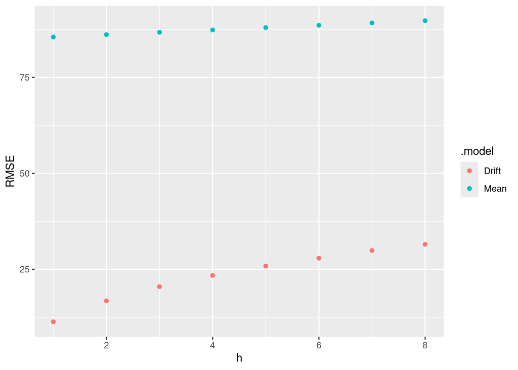

```r
summary_cv_h |>
  ggplot(aes(x = h, y = RMSE, color = .model)) +
  geom_point()
```

As you can see the graph indicates that the average performance of the drift model over all the train-test splits is much better (smaller errors) than that of the mean method for this particular time series for all the forecast horizons analyzed.

#### 4.2 Option 2: generate average accuracy metrics for each model averaged over all the forecasting horizons.

Perhaps we are not interested in producing forecasts with a specific horizon, but rather we would like a model that returns the best forecasts on average over all the horizons.

To attain this, we use again the `accuracy()` function but we do not provide an argument for `by`. It will therefore default to grouping solely by `.model` and the `Key` identifier of the time series. Let us check this:

```r
google_2015_fc_cv |>
  accuracy(google_2015)
```

```
# A tibble: 2 × 10
  .model .type    ME  RMSE   MAE   MPE  MAPE  MASE RMSSE  ACF1
  <chr>  <chr> <dbl> <dbl> <dbl> <dbl> <dbl> <dbl> <dbl> <dbl>
1 Drift  Test   2.21  24.2  15.3 0.272  2.48  2.15  2.16 0.814
2 Mean   Test  62.6   87.7  64.7 9.17   9.57  9.08  7.83 0.966
```

This is equivalent to doing:

```r
google_2015_fc_cv |>
  accuracy(google_2015, by = c(".model"))
```

```
# A tibble: 2 × 10
  .model .type    ME  RMSE   MAE   MPE  MAPE  MASE RMSSE  ACF1
  <chr>  <chr> <dbl> <dbl> <dbl> <dbl> <dbl> <dbl> <dbl> <dbl>
1 Drift  Test   2.21  24.2  15.3 0.272  2.48  2.15  2.16 0.814
2 Mean   Test  62.6   87.7  64.7 9.17   9.57  9.08  7.83 0.966
```

The above metrics are the average performance metrics of each of the model types over all the train-test splits and forecast horizons. For example:

- The row corresponding to the `Drift` contains the error metrics of the drift model averaged over the 233 train-test splits and over all the forecast horizons.

## Exercise: cross-validation

### Task

Perform cross-validation on the Australian beer production time series. Use the dataset `recent_production` created further down below.

### Step 0. Identify your dataset and think about which variables you need

- We will work with `recent_production`, specifically with the production of beer, which we will store in `beer_production`. We will apply `stretch_tsibble()` to this time series to generate our set of training datasets.
- For convenience, I will select only the variables relevant to the analysis.

```r
recent_production <- aus_production |>
  filter(year(Quarter) >= 1992)
```

```r
beer_production <- select(recent_production, Quarter, Beer)
beer_production
```

```
# A tsibble: 74 x 2 [1Q]
   Quarter  Beer
     <qtr> <dbl>
 1 1992 Q1   443
 2 1992 Q2   410
 3 1992 Q3   420
 4 1992 Q4   532
 5 1993 Q1   433
 6 1993 Q2   421
 7 1993 Q3   410
 8 1993 Q4   512
 9 1994 Q1   449
10 1994 Q2   381
# ℹ 64 more rows
```

### Step 1. Create the set of training datasets using `stretch_tsibble()`

### Step 2: Fit the models

### Step 3: generate the forecasts

Consider a forecast horizon of up to 4.

### Step 4: generate cross-validated accuracy metrics

#### 4.1 Option 1: generate accuracy metrics for each combination of model and forecast horizon.

#### 4.2 Option 2: generate average accuracy metrics for each model averaged over all the forecasting horizons.